# Geospatial Data Fundamentals in R

# Lesson 2. Introduction to the `sf` package

In this lesson we’ll learn about `sf`, the primary package for working with **vector** geospatial data in R. We’ll go through the structure of the `sf` data object (it’s not too different from a regular data.frame!), the types of `sf` geometries, reading in data from files like the ESRI shapefile, and how to save your hard work to a new file.

- 2.1 What is the `sf` package?
- 2.2 Spatial data input with `st_read`
- 2.3 Plot the `sf` object
- 2.4 Explore the `sf` object
- 2.5 Subset the `sf` object
- 2.6 Save your data with `st_write`
- 2.7 Recap
- **Exercise**: File IO, Manipulation, and Mapping

##### Instructor Notes

###### Datasets used

- California county shapefiles with demographic data (‘notebook_data/california_counties/CaliforniaCounties.shp’)
- California places cartographic boundaries for 2019 from the United States Census Bureau (‘notebook_data/census/Places/cb_2019_06_place_500k.zip’)

###### Expected time to complete

- Lecture + Questions: 40 minutes
- Exercises: 5 minutes

## 2.1 What is `sf`?

### The `sf` package

[`sf`](https://r-spatial.github.io/sf/) is a relatively new package that makes it easier to work with geospatial data in R. In the last few years it has grown more stable and more widely used. This is really great because the previous go to package for working with vector geospatial data in R, the `sp` package, was more complicated. However, although `sf` is now the go-to package for working with `vector` geospatial data in R, some older spatial data packages still require the use of `sp`, so you may run into it.

> **Tip**: If you work with `raster` data you will want to checkout the [raster](https://cran.r-project.org/web/packages/raster/index.html) package.

### `sf` = simple features

`sf` provides object classes and functions for working with geospatial data. The primary `sf` object class is the spatial dataframe. An sf spatial dataframe retains all of the functionality of an R `data.frame` extended with a geometry column, metadata about the geometry column, and functions for working with the geometry. This makes it possible to process your data using both standard table-based operations and explicitly geospatial operations from the `sf` library.

### References

There are two primary sources on which this workshop is based. I encourage anyone interested in learning about `sf` in depth to read through both of these.

- The [Geocomputation with R](https://geocompr.robinlovelace.net/) textbook (Lovelace, Nowosad, and Muenchow, 2019) is an excellent resource for getting up and running.
- The [R sf package](https://r-spatial.github.io/sf/) webpage, especially the Articles tab of tutorials for getting started.

### Load the `sf` Library

Let’s start by loading the `sf` library (as well as the `here` library, which provides a `here()` command that builds file paths from the project directory).

```r
library(sf)
library(here)
```

## 2.2 Read in a shapefile with `st_read`

The first step in most data analysis workflows is to load data from a file on your computer into the software you are using. We will read in an **ESRI Shapefile** with the `st_read` function.

The [ESRI shapefile](https://en.wikipedia.org/wiki/Shapefile) is the most widely used type of file format for storing geospatial vector data.

The tricky thing to remember about a shapefile is that it is actually a collection of 3 or more files. Here’s a list of some of the files commonly included in a shapefile:

- **Mandatory**:
  - `shp`: The main file that stores the feature geometry
  - `shx`: A positional index for locating the feature geometry in the `shp` file
  - `dbf`: The data table (in dBase IV format) that stores the attribute information for each feature
- **Optional**
  - `prj`: Stores the coordinate reference system information. (**should be required!**)
  - `sbn` and `sbx`: spatial index to speed up geometry operations - *used only by ESRI software*
  - `xml`: Metadata — Stores information about the shapefile.
  - `cpg`: Specifies the code page for identifying the character encoding set to be used.

The shapefile can be a pain because of this structure! The files need to be kept together in the same directory and are typically distributed as zip files.

### Shapefile limitations

The shapefile also has some serious limitations, including:

- none of the component files can exceed 2GB
- column names cannot be longer than 10 characters
- the number of columns is limited to 255
- unicode support is weak, e.g. apostrophes (single quotes) can crash the software

It’s an old file format, but it remains the most commonly used file format for vector spatial data!

### California Counties

We are going to read in a shapefile with California county data.

First, take a look at the shapefile on your computer using the RStudio `Files` browser and then with the R `dir()` command

```r
dir(path = here("notebook_data",
                "california_counties"))
```

```
## [1] "CaliforniaCounties.dbf"     "CaliforniaCounties.prj"
## [3] "CaliforniaCounties.shp"     "CaliforniaCounties.shp.xml"
## [5] "CaliforniaCounties.shx"
```

Above we use the `here` function to view the files in a folder. You can also reference the folder directly, using it’s relative file system path as shown below. However, if you get the path wrong you cannot access files and folders. So the `here` package makes it easier for you to locate these.

```r
dir('../notebook_data/california_counties')
```

```
## [1] "CaliforniaCounties.dbf"     "CaliforniaCounties.prj"
## [3] "CaliforniaCounties.shp"     "CaliforniaCounties.shp.xml"
## [5] "CaliforniaCounties.shx"
```

### Load the data into R

Now use `st_read` to load the data into R. Take a look at the info st_read outputs as it loads the data.

```r
# Read in the counties shapefile
counties = st_read(dsn = here("notebook_data",
                              "california_counties",
                              "CaliforniaCounties.shp"))
```

[output not shown]

## 2.3 Plotting Spatial Data

One of the first things one does with geospatial data after loading it into R is to make a simple map of the data. You can do that with the `sf::plot` function which extends the base R plot command to work with `sf` data objects.

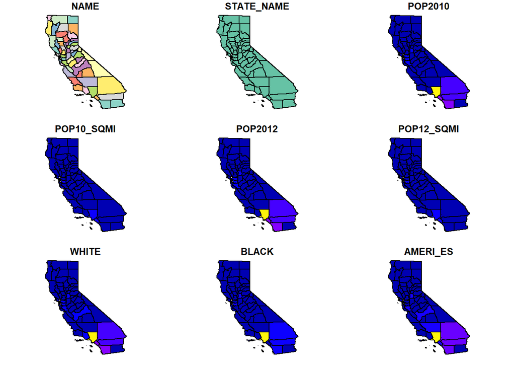

```r
# Plot out California counties
plot(counties)
```

That gives us a grid of maps where colors are used to symbolize the data values in the first 9 columns (i.e. attributes) of the sf dataframe.

That can be tedious for a large dataframe. What if we just want to map the data by a single variable?

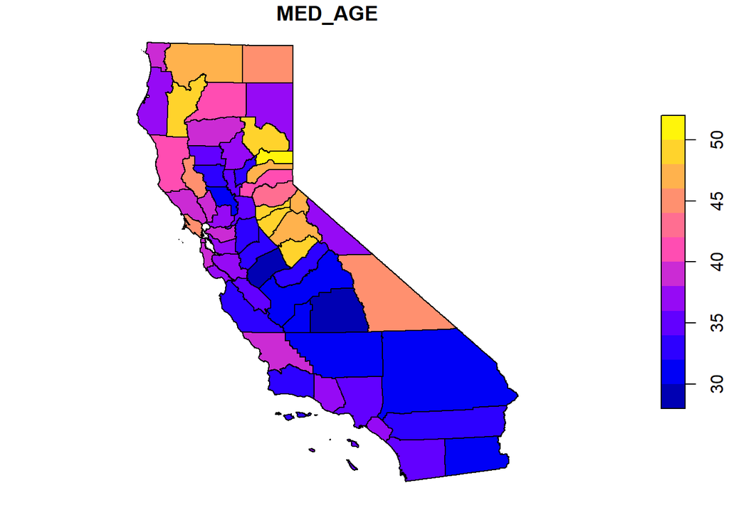

```r
plot(counties['MED_AGE'])
```

> A `choropleth` map is a thematic map where data values are used to symbolize polygons.

We’re off to a running start.

### Mapping Just the Geometry

To make a map the geometry without setting the color by the data values, you can plot the geometry column.

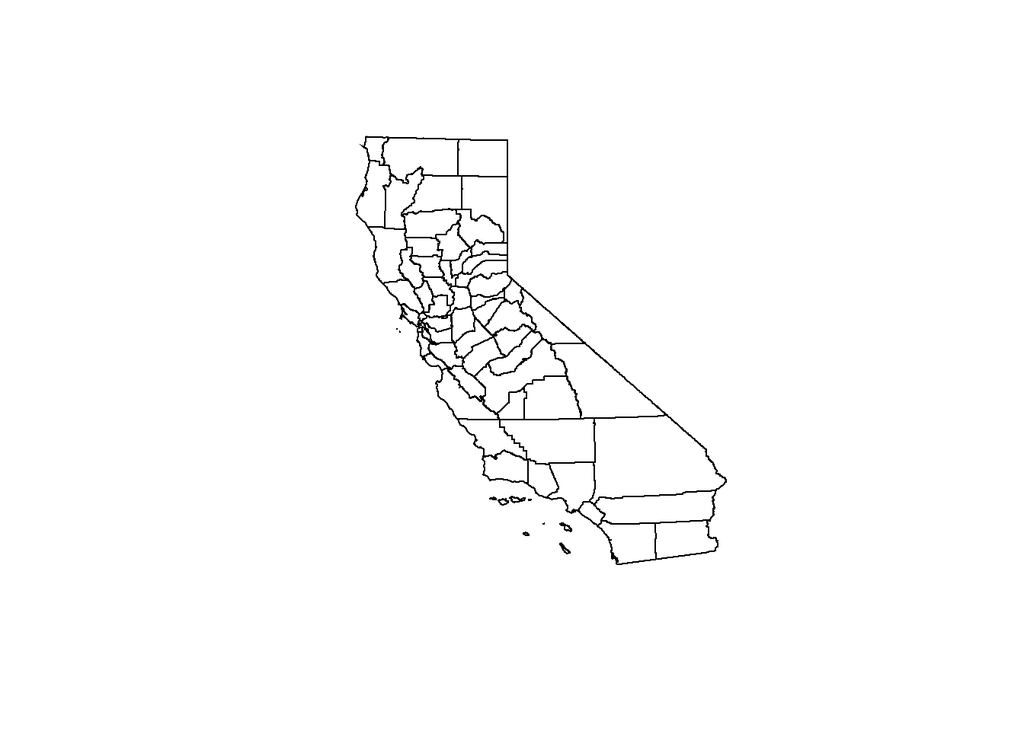

```r
plot(counties['geometry'])
```

There are some variations on the plot command that only map the geometry column.

```r
plot(counties$geometry)
plot(counties[['geometry']])
plot(st_geometry(counties))
```

## 2.4 Explore the `sf` Spatial data.frame

Before we get in too deep, let’s discuss what a `sf spatial data.frame` is, and how it’s different from a standard R `data.frame`.

A `sf spatial data.frame`, or more formally, an `sf` **simple feature collection object**, is just like a standard R `data.frame`, but with an extra geometry column. The `sf` package includes additional functions that operate on that geometry column. We’ve used a few already!

I repeat because it’s important:

> `An sf object is a standard R data.frame extended with spatial data (geometry) and spatial operations.`

*In case you are wondering, an sf object can have more than one geometry column, but only one geometry column is considered active.*

This means all the standard R operations that we can run on a `data.frame will also work on`sf` spatial dataframe!

With that in mind, let’s start exploring our `sf` object just like we would a dataset in a plain `data.frame`.

```r
# Find the number of rows and columns in counties
dim(counties)
```

```
## [1] 58 25
```

```r
# Look at the first few rows of our sf object
counties
```

```
## Simple feature collection with 58 features and 24 fields
## Geometry type: MULTIPOLYGON
## Dimension:     XY
## Bounding box:  xmin: -374445.4 ymin: -604500.7 xmax: 540038.5 ymax: 450022
## Projected CRS: NAD83 / California Albers
## First 10 features:
##           NAME STATE_NAME POP2010 POP10_SQMI POP2012  POP12_SQMI   WHITE  BLACK
## 1         Kern California  839631      102.9  851089  104.282870  499766  48921
## 2        Kings California  152982      109.9  155039  111.427421   83027  11014
## 3         Lake California   64665       48.6   65253   49.082334   52033   1232
## 4       Lassen California   34895        7.4   35039    7.422856   25532   2834
## 5  Los Angeles California 9818605     2402.3 9904341 2423.264150 4936599 856874
## 6       Madera California  150865       70.1  153025   71.065672   94456   5629
## 7        Marin California  252409      480.2  255509  486.100489  201963   6987
## 8     Mariposa California   18251       12.5   18455   12.613887   16103    138
```

[output cut: 35 more lines]

```r
# Look at all the variables included in our data
colnames(counties)
```

```
##  [1] "NAME"       "STATE_NAME" "POP2010"    "POP10_SQMI" "POP2012"
##  [6] "POP12_SQMI" "WHITE"      "BLACK"      "AMERI_ES"   "ASIAN"
## [11] "HAWN_PI"    "HISPANIC"   "OTHER"      "MULT_RACE"  "MALES"
## [16] "FEMALES"    "MED_AGE"    "AVE_HH_SZ"  "AVE_FAM_SZ" "HSE_UNITS"
## [21] "VACANT"     "OWNER_OCC"  "RENTER_OCC" "CountyFIPS" "geometry"
```

This CA Counties data contains a good amount of information including population totals and densities, as well as race, age, and occupancy info.

*Do you notice anything inconsistent in the output of `dim`, `head`, `colnames`?*

## 2.4 `sf` Geometries

We are able to map our `sf` object because of the data in the `geometry` column.

#### A sf spatial data frame..

- is a simple feature collection
- where each row contains a feature (geometry + the column attributes that describe it)
  - and each feature contains a `simple feature geometry list column (sfc)`
    - which in turn contains `simple feature geometry (sfg)`

Let’s take a closer look at the counties sf object

```r
# What class of object is it?
class(counties)
```

```
## [1] "sf"         "data.frame"
```

```r
# What about the geometry column?
class(counties$geometry)
```

```
## [1] "sfc_MULTIPOLYGON" "sfc"
```

```r
# What about the geometry for the first feature?
class(counties$geometry[[1]])
```

```
## [1] "XY"           "MULTIPOLYGON" "sfg"
```

> **Question** Based on the output of the head command below, can you guess why they call the geometry column `sticky`?

```r
# Take a look at the first 5 rows, and first 4 cols
head(counties[1:5,1:4])
```

```
## Simple feature collection with 5 features and 4 fields
## Geometry type: MULTIPOLYGON
## Dimension:     XY
## Bounding box:  xmin: -267387.9 ymin: -578158.6 xmax: 216677.6 ymax: 352693.6
## Projected CRS: NAD83 / California Albers
##          NAME STATE_NAME POP2010 POP10_SQMI                       geometry
## 1        Kern California  839631      102.9 MULTIPOLYGON (((213672.6 -2...
## 2       Kings California  152982      109.9 MULTIPOLYGON (((12524.03 -1...
## 3        Lake California   64665       48.6 MULTIPOLYGON (((-235734.3 1...
## 4      Lassen California   34895        7.4 MULTIPOLYGON (((12.28914 35...
## 5 Los Angeles California 9818605     2402.3 MULTIPOLYGON (((173874.5 -4...
```

### sf Geometry Types

There are three main types of geometries that can be associated with `sf` object: points, lines and polygons:

In an `sf data.frame` these geometries are encoded in a format known as [Well-Known Text (WKT)](https://en.wikipedia.org/wiki/Well-known_text_representation_of_geometry). For example:

> - POINT (30 10)
> - LINESTRING (30 10, 10 30, 40 40)
> - POLYGON ((30 10, 40 40, 20 40, 10 20, 30 10))

> *where X,Y coordinate values are separated by a space, coordinate pairs by a comma, and geometries by parentheses*

An `sf` object may also include the variants **multipoints, multilines, and multipolgyons** if some of the features are composed multiple and or complex geometries.

> - MULTIPOINT ((10 40), (40 30), (20 20), (30 10))
> - MULTILINESTRING ((10 10, 20 20, 10 40), (40 40, 30 30, 40 20, 30 10))
> - MULTIPOLYGON (((30 20, 45 40, 10 40, 30 20)), ((15 5, 40 10, 10 20, 5 10, 15 5)))

For example, if we had data representing US states (one per row), we could use a POLYGON geometry for states like Utah or Colorado, but would need a MULTIPOLYGON for states like Hawaii, which includes many islands.

> **Question** What kind of geometry would a roads `sf` object have? What about one that includes landmarks in the San Francisco Bay Area?

### Making your own sf objects

You can hand code your own sf objects, but most people just read in spatial data from a file!

```r
p <- rbind(c(10, 40), c(40, 30), c(20, 20), c(30, 10))
(mp <- st_multipoint(p))
```

```
## MULTIPOINT ((10 40), (40 30), (20 20), (30 10))
```

```r
plot(mp)
```

[output not shown]

## 2.5 Attribute Operations with `sf` Objects

To get a better sense of the ways in which a spatial dataframe is like a standard R dataframe, let’s practice working with the counties attribute data.

### Subset columns

Let’s create a new sf object that includes all rows but only a subset of columns.

```r
counties2 = counties[c('NAME','POP2012','MED_AGE')]
head(counties2)
```

```
## Simple feature collection with 6 features and 3 fields
## Geometry type: MULTIPOLYGON
## Dimension:     XY
## Bounding box:  xmin: -267387.9 ymin: -578158.6 xmax: 216677.6 ymax: 352693.6
## Projected CRS: NAD83 / California Albers
##          NAME POP2012 MED_AGE                       geometry
## 1        Kern  851089    30.7 MULTIPOLYGON (((213672.6 -2...
## 2       Kings  155039    31.1 MULTIPOLYGON (((12524.03 -1...
## 3        Lake   65253    45.0 MULTIPOLYGON (((-235734.3 1...
## 4      Lassen   35039    37.0 MULTIPOLYGON (((12.28914 35...
## 5 Los Angeles 9904341    34.8 MULTIPOLYGON (((173874.5 -4...
## 6      Madera  153025    33.1 MULTIPOLYGON (((16681.16 -1...
```

> **Question** What is interesting to note in the output above?

Now rename the columns in our subset. (not run)

```r
colnames(counties2)<- c('county', 'pop2012', 'median_age')
head(counties2)
```

> Takeawy: Don’t get stuck on sticky geometry!

### Subset rows by column value

Since we’ll be focusing on Berkeley later in the workshop, let’s subset our counties to create a new `sf` object for Alameda County.

```r
# See the vector of all county names included in our dataset
sort(counties$'NAME')
```

```
##  [1] "Alameda"         "Alpine"          "Amador"          "Butte"
##  [5] "Calaveras"       "Colusa"          "Contra Costa"    "Del Norte"
##  [9] "El Dorado"       "Fresno"          "Glenn"           "Humboldt"
## [13] "Imperial"        "Inyo"            "Kern"            "Kings"
## [17] "Lake"            "Lassen"          "Los Angeles"     "Madera"
## [21] "Marin"           "Mariposa"        "Mendocino"       "Merced"
## [25] "Modoc"           "Mono"            "Monterey"        "Napa"
## [29] "Nevada"          "Orange"          "Placer"          "Plumas"
## [33] "Riverside"       "Sacramento"      "San Benito"      "San Bernardino"
## [37] "San Diego"       "San Francisco"   "San Joaquin"     "San Luis Obispo"
## [41] "San Mateo"       "Santa Barbara"   "Santa Clara"     "Santa Cruz"
## [45] "Shasta"          "Sierra"          "Siskiyou"        "Solano"
## [49] "Sonoma"          "Stanislaus"      "Sutter"          "Tehama"
## [53] "Trinity"         "Tulare"          "Tuolumne"        "Ventura"
## [57] "Yolo"            "Yuba"
```

It looks like Alameda County is specified simply as “Alameda” in this dataset.

```r
counties[counties$NAME == 'Alameda',]
```

```
## Simple feature collection with 1 feature and 24 fields
## Geometry type: MULTIPOLYGON
## Dimension:     XY
## Bounding box:  xmin: -205957.9 ymin: -60728.4 xmax: -129674.4 ymax: -9909.857
## Projected CRS: NAD83 / California Albers
##       NAME STATE_NAME POP2010 POP10_SQMI POP2012 POP12_SQMI  WHITE  BLACK
## 35 Alameda California 1510271     2029.8 1534551   2062.402 649122 190451
##    AMERI_ES  ASIAN HAWN_PI HISPANIC  OTHER MULT_RACE  MALES FEMALES MED_AGE
## 35     9799 394560   12802   339889 162540     90997 740573  769698    36.6
##    AVE_HH_SZ AVE_FAM_SZ HSE_UNITS VACANT OWNER_OCC RENTER_OCC CountyFIPS
## 35       2.7        3.3    582549  37411    291242     253896      06068
##                          geometry
## 35 MULTIPOLYGON (((-197580.8 -...
```

Now we can save that subset by creating a new `sf` object called `alameda_county.

```r
alameda_county = counties[counties$NAME == 'Alameda',]
```

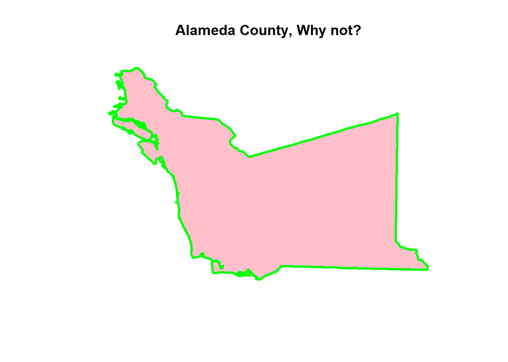

```r
# Plot our newly subsetted sf object
plot(alameda_county$geometry, col='pink', border='green', lwd=3, main='Alameda County, Why not?')
```

Nice! Looks like we have what we were looking for.

### Plotting overlays

Map overlays are one of the most powerful methods for visualizing spatial data. We can create these with the basic `plot` command.

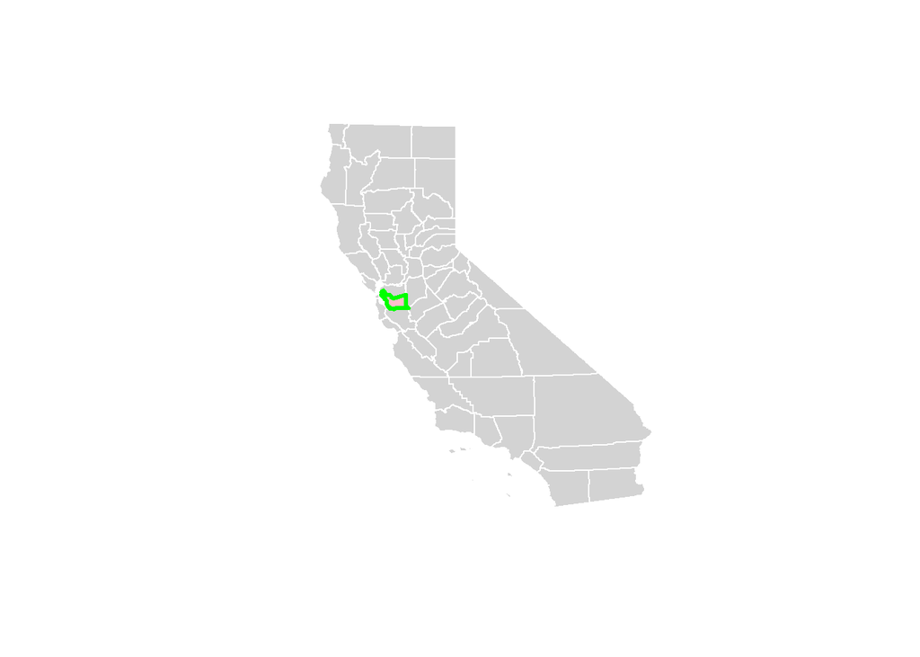

```r
# Plot our newly subsetted sf object
plot(counties$geometry, col='lightgrey', border='white')
plot(alameda_county$geometry, col='pink', border='green', lwd=3, main='Alameda County, Why not?', add=TRUE)
```

> In the next lessons we will spend more time creating maps and map overlays.

Let’s save out our `alameda_county` object. This way we won’t need to repeat the processing steps we did above.

## 2.6 Save Your Data

We can output`sf` objects to files using the **st_write** command.

`st_write` supports a wide range of output geographic vector file formats. It automatically determines the output file type based on the filename you specify.

### Save to a Shapefile

```r
# Save to shapefile, deleting existing file if present
st_write(alameda_county,
         here("outdata",
              "alameda_county.shp"),
         delete_dsn = T)
```

```
## Deleting source `C:/Users/bill.chung/OneDrive - Danaher/Documents/GitHub/R-Geospatial-Fundamentals/outdata/alameda_county.shp' using driver `ESRI Shapefile'
## Writing layer `alameda_county' to data source
##   `C:/Users/bill.chung/OneDrive - Danaher/Documents/GitHub/R-Geospatial-Fundamentals/outdata/alameda_county.shp' using driver `ESRI Shapefile'
## Writing 1 features with 24 fields and geometry type Multi Polygon.
```

One of the problems of saving to a shapefile is that our column names get truncated to 10 characters (a shapefile limitation.)

Instead of renaming all columns with obscure names that are less than 10 characters, we can save our `sf` object to a spatial data file format that does not have this limitation, such as the GeoJSON file format or the [GPKG](https://en.wikipedia.org/wiki/GeoPackage) (geopackage) file format.

- These formats have the added benefit of outputting only one file in contrast to the multi-file shapefile format.

### Save to a GeoJSON file

```r
st_write(alameda_county,
         here("outdata",
              "alameda_county.geojson"),
         delete_dsn = T)
```

```
## Deleting source `C:/Users/bill.chung/OneDrive - Danaher/Documents/GitHub/R-Geospatial-Fundamentals/outdata/alameda_county.geojson' using driver `GeoJSON'
## Writing layer `alameda_county' to data source
##   `C:/Users/bill.chung/OneDrive - Danaher/Documents/GitHub/R-Geospatial-Fundamentals/outdata/alameda_county.geojson' using driver `GeoJSON'
## Writing 1 features with 24 fields and geometry type Multi Polygon.
```

```r
# or
st_write(alameda_county,
         here("outdata",
              "alameda_county.json"),
              driver="GeoJSON",
              delete_dsn = T)
```

```
## Deleting source `C:/Users/bill.chung/OneDrive - Danaher/Documents/GitHub/R-Geospatial-Fundamentals/outdata/alameda_county.json' using driver `GeoJSON'
## Writing layer `alameda_county' to data source
##   `C:/Users/bill.chung/OneDrive - Danaher/Documents/GitHub/R-Geospatial-Fundamentals/outdata/alameda_county.json' using driver `GeoJSON'
## Writing 1 features with 24 fields and geometry type Multi Polygon.
```

### Save to a [GPKG](https://en.wikipedia.org/wiki/GeoPackage) (geopackage) file

```r
st_write(alameda_county,
         here("outdata",
              "alameda_county.gpkg"),
         delete_dsn = T)
```

```
## Deleting source `C:/Users/bill.chung/OneDrive - Danaher/Documents/GitHub/R-Geospatial-Fundamentals/outdata/alameda_county.gpkg' using driver `GPKG'
## Writing layer `alameda_county' to data source
##   `C:/Users/bill.chung/OneDrive - Danaher/Documents/GitHub/R-Geospatial-Fundamentals/outdata/alameda_county.gpkg' using driver `GPKG'
## Writing 1 features with 24 fields and geometry type Multi Polygon.
```

### Save to CSV file

You can even ouput geospatial data to CSV - *check out the resultant file.*

```r
st_write(alameda_county,
         here("outdata",
              "alameda_county.csv"),
         layer_options="GEOMETRY=AS_WKT",
         delete_dsn = T)
```

```
## Deleting source `C:/Users/bill.chung/OneDrive - Danaher/Documents/GitHub/R-Geospatial-Fundamentals/outdata/alameda_county.csv' using driver `CSV'
## Writing layer `alameda_county' to data source
##   `C:/Users/bill.chung/OneDrive - Danaher/Documents/GitHub/R-Geospatial-Fundamentals/outdata/alameda_county.csv' using driver `CSV'
## options:        GEOMETRY=AS_WKT
## Writing 1 features with 24 fields and geometry type Multi Polygon.
```

Use the RStudio Files panel to view the files you just wrote to the `outdata` folder.

### Practice reading in these files

To review, you can read these in any of these files with `st_read`. Give it a try, plotting just the geometry column.

```r
shp_test = st_read(...)
plot(...)
```

```r
json_test = st_read(...)
plot(...)
```

```r
csv_test = st_read(...)
plot(...)
```

**NOTE**: If you’re working with point data (i.e. a single latitude and longitude value per feature), then CSV might be a good option! Otherwise, may be a big file!

## 2.7 Recap

In this lesson we learned about…

- The `sf` package
- Reading in shapefiles
  - `st_read`
- `sf` data structures
  - `dim`, `head`, `colnames`, `str`
- Plotting `sf` objects
  - `plot`
- Subsetting `sf` objects
  - by attribute
- Saving `sf` objects to file
  - `st_write`

## Exercise: IO, Manipulation, and Mapping

Now you’ll get a chance to practice the operations we learned above.

In the following cell, compose code to:

1. Read in the California places data (`notebook_data/census/Places/cb_2019_06_place_500k.shp`)
2. Make a map of the CA Places geometry
3. Subset the CA Places data to keep only Berkeley
4. Plot Berkeley using base and customize the border and fill colors
5. Map the Berkeley geometry in a bright color over the CA PLaces geometry
6. Save out Berkeley as a shapefile (`outdata/berkeley_places.shp`)

```r
# YOUR CODE HERE
```

### Solution hidden here!

*To see it, right-click and select “inspect element” in your browser (or look in the `04_Introduction_to_sf.Rmd` file near line 440).*

D-Lab @ University of California - Berkeley

Team Geo